# Prediction using UnSupervised ML

## Data Visualization

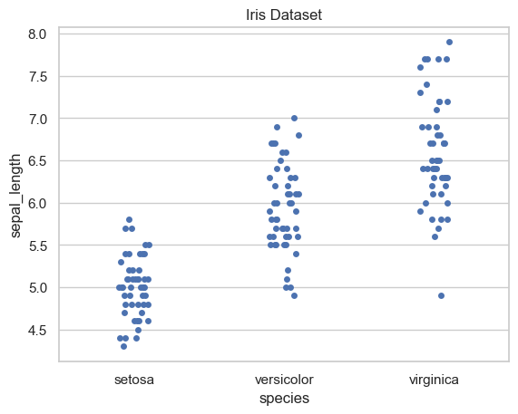

```python
sns.set(style = 'whitegrid')
iris = sns.load_dataset('iris');
ax = sns.stripplot(x = 'species', y = 'sepal_length', data = iris);
plt.title('Iris Dataset')
plt.show()
```

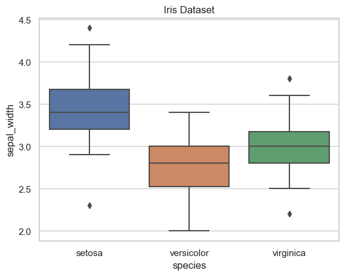

```python
sns.boxplot(x = 'species', y = 'sepal_width', data = iris)
plt.title("Iris Dataset")
plt.show()
```

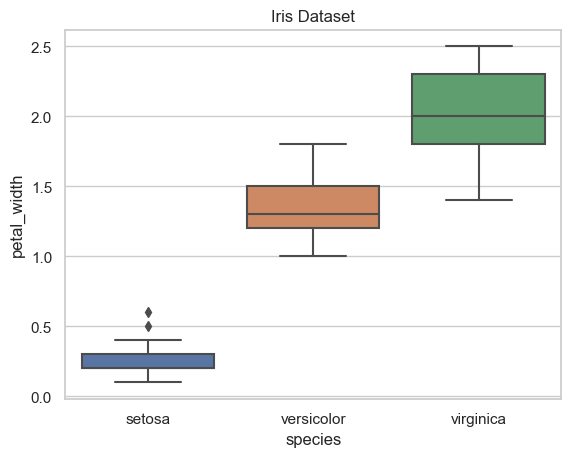

```python
sns.boxplot(x = 'species', y = 'petal_width', data = iris)
plt.title("Iris Dataset")
plt.show()
```

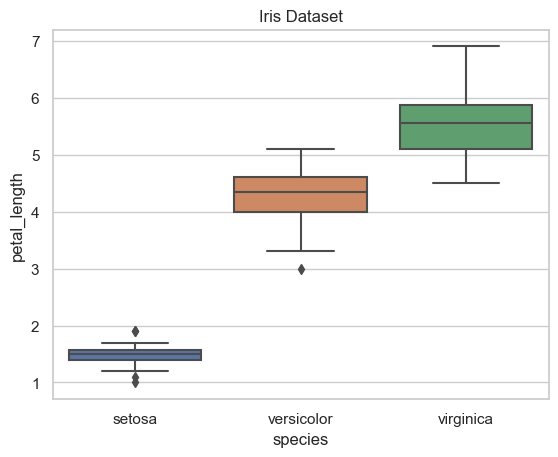

```python
sns.boxplot(x='species',y='petal_length',data=iris)
plt.title("Iris Dataset")
plt.show()
```

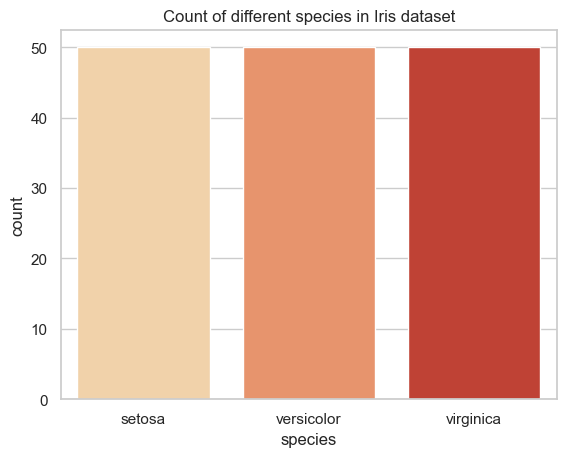

```python
# Count plot
sns.countplot(x='species', data=iris, palette="OrRd")
plt.title("Count of different species in Iris dataset")
plt.show()
```

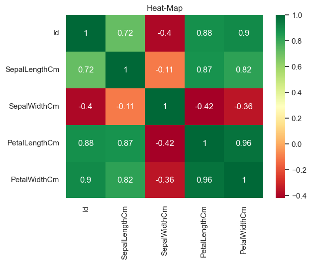

```python
#This is needed for the analysis of two variables, for determining the empirical relationship between them.
sns.heatmap(data.corr(), annot=True, cmap='RdYlGn')
plt.title("Heat-Map")
plt.show()
```

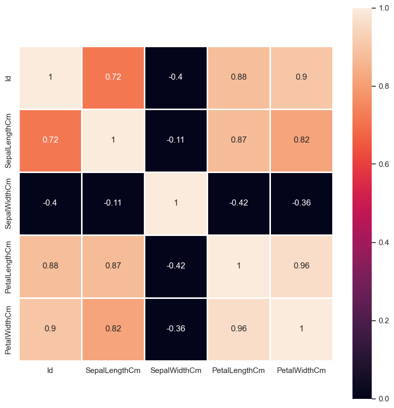

```python
iris1 = data.corr() #finding correlation between variables of iris dataset
fig, ax = plt.subplots(figsize=(10,10))
sns.heatmap(iris1, vmin=0, vmax=1, square=True, annot=True, linewidths=1)
plt.show()
```

Heatmap is a two-dimensional graphical representation of data where the individual values that are contained in a matrix are represented as colors. Or we can also say that these Heat maps display numeric tabular data where the cells are colored depending upon the contained value.

Heat maps are great for making trends in this kind of data more readily apparent, particularly when the data is ordered and there is clustering.

The columns with the correlation 1 are the best correlated and vice versa.

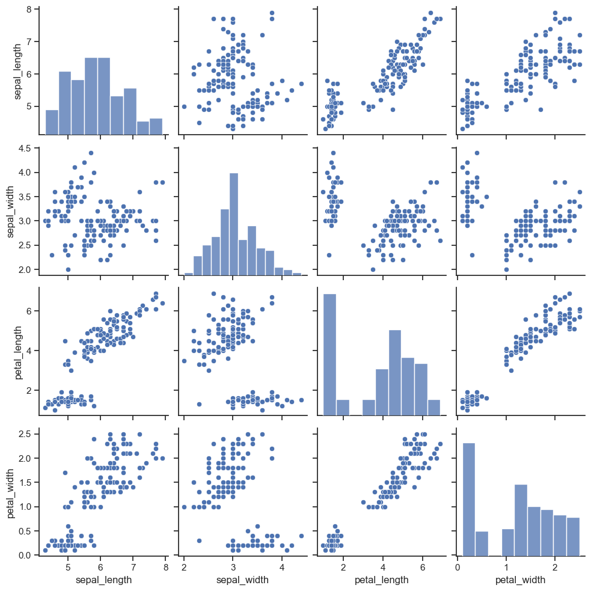

```python
import seaborn as sns

sns.set(style="ticks", color_codes=True)
iris = sns.load_dataset("iris")
g = sns.pairplot(iris)


import matplotlib.pyplot as plt
plt.show()
```

Pairplots are a really simple way to visualize relationships between each variable. It produces a matrix of relationships between each variable in the data for an instant examination of our data.